# Linear Regression with Least Squares Method

This notebook implements linear regression manually using the method of least squares.

The regression supports:

- Linear functions
- Polynomial functions
- Mmultilinear functions

## Load the data

This function reads a file where the last column is the output and the rest are input variables.

```python
import os
import pandas as pd
import matplotlib.pyplot as plt

def loadData(filePath):
    data = pd.read_csv(filePath, sep=r'\s+')
    x = data.iloc[:, :-1].values.astype(float)
    y = data.iloc[:, -1].values.astype(float)
    return x, y
```

## Matrix operations

These functions are written manually:

- Matrix transposition
- Matrix multiplication
- Matrix inversion

```python
def transposeMatrix(matrix):
    rows, cols = len(matrix), len(matrix[0])
    return [[matrix[r][c] for r in range(rows)] for c in range(cols)]

def matrixMultiply(a, b):
    result = [[0.0 for _ in range(len(b[0]))] for _ in range(len(a))]
    for i in range(len(a)):
        for j in range(len(b[0])):
            for k in range(len(b)):
                result[i][j] += a[i][k] * b[k][j]
    return result

def invertMatrix(matrix):
    n = len(matrix)
    identity = [[float(i == j) for j in range(n)] for i in range(n)]

    # keep original matrix
    mat = [row[:] for row in matrix]

    for i in range(n):
        diag = mat[i][i]
        if diag == 0:
            for k in range(i+1, n):
                if mat[k][i] != 0:
                    mat[i], mat[k] = mat[k], mat[i]
                    identity[i], identity[k] = identity[k], identity[i]
                    diag = mat[i][i]
                    break
            else:
                raise ValueError("Matrix is singular and cannot be inverted.")

        for j in range(n):
            mat[i][j] /= diag
            identity[i][j] /= diag

        for k in range(n):
            if k == i:
                continue
            factor = mat[k][i]
            for j in range(n):
                mat[k][j] -= factor * mat[i][j]
                identity[k][j] -= factor * identity[i][j]

    return identity
```

## Data centering

Before applying regression, subtract the mean from each column of X and from Y.

```python
def meanColumn(matrix):
    rows = len(matrix)
    cols = len(matrix[0])
    return [sum(matrix[i][j] for i in range(rows)) / rows for j in range(cols)]

def centerMatrix(matrix, means):
    return [[matrix[i][j] - means[j] for j in range(len(matrix[0]))] for i in range(len(matrix))]

def centerVector(vec, mean):
    return [val - mean for val in vec]
```

## Helper conversions

These functions convert between vectors and column-matrices to make multiplication easier.

```python
def vectorToMatrixColumn(vec):
    return [[val] for val in vec]

def matrixColumnToVector(matrix):
    return [row[0] for row in matrix]

def linspace(start, stop, num):
    step = (stop - start) / (num - 1)
    return [start + i * step for i in range(num)]
```

## Add polynomial features

It expands a single input X into powers: X, X2, X2, ..., Xn.

```python
def addPolynomialFeatures(x, degree):
    poly = []
    for row in x:
        newRow = []
        for d in range(1, degree + 1):
            newRow.append(row[0] ** d)
        poly.append(newRow)
    return poly
```

## Calculate regression coefficients

This uses the least squares formula:  
b = (X^T * X)^(-1) * X^T * y  
where b is the list of coefficients (not b0).

```python
def calculateCoefficients(x, y):
    xT = transposeMatrix(x)
    xTx = matrixMultiply(xT, x)
    xTxInv = invertMatrix(xTx)
    xTy = matrixMultiply(xT, vectorToMatrixColumn(y))
    b = matrixMultiply(xTxInv, xTy)
    return matrixColumnToVector(b)
```

## Calculate intercept (b0)

This is computed from the mean of Y and the means of X columns:  
b0 = mean(Y) - sum(bi * mean(Xi))

```python
def calculateB0FromMeans(xMeans, yMean, b):
    return yMean - sum(b[i] * xMeans[i] for i in range(len(b)))

def calculateB0(x, y, b):
    total = 0
    for i in range(len(x)):
        pred = sum(x[i][j] * b[j] for j in range(len(b)))
        total += y[i] - pred
    return total / len(x)
```

## Predict using the learned model

This calculates predicted values y = b0 + b1x1 + b2x2 + ...

```python
def predict(x, b0, b):
    return [b0 + sum(x[i][j] * b[j] for j in range(len(b))) for i in range(len(x))]
```

## Visualizing regression

This plot shows how the learned function fits the original data.

```python
def visualizeLinearFit(x, y, b0, b):
    xVals = [row[0] for row in x]
    yVals = y
    xLine = linspace(min(xVals), max(xVals), 100)
    yLine = [b0 + b[0] * xi for xi in xLine]

    plt.figure(figsize=(6, 4))
    plt.scatter(xVals, yVals, label="Original Data")
    plt.plot(xLine, yLine, color='red', label="Regression Line")
    plt.xlabel("X")
    plt.ylabel("Y")
    plt.title("Linear Regression Fit")
    plt.legend()
    plt.grid(True)
    plt.show()

def visualizePolynomialFit(xOriginal, y, b0, b):
    xVals = [row[0] for row in xOriginal]
    xLine = linspace(min(xVals), max(xVals), 100)

    yLine = []
    for xi in xLine:
        prediction = b0
        for power, coeff in enumerate(b, start=1):
            prediction += coeff * (xi ** power)
        yLine.append(prediction)

    plt.figure(figsize=(6, 4))
    plt.scatter(xVals, y, label="Original Data")
    plt.plot(xLine, yLine, color='green', label="Polynomial Fit")
    plt.xlabel("X")
    plt.ylabel("Y")
    plt.title("Polynomial Regression Fit")
    plt.legend()
    plt.grid(True)
    plt.show()

def displayMultivariableEquation(b0, b):
    terms = [f"{round(coeff, 2)}*x{i+1}" for i, coeff in enumerate(b)]
    equation = f"y = {round(b0, 2)} + " + " + ".join(terms)
    print("Multivariable regression model:")
    print(equation)
```

## Run regression on a folder

This function handles loading, centering, coefficient calculation, and printing results.  
It automatically chooses polynomial expansion if needed.

```python
def runRegressionFromFolder(folderName):
    filePath = os.path.join("TestniPodatki", folderName, "Podatki.txt")
    x, y = loadData(filePath)

    if x.shape[1] == 1 and folderName == "Polinomska funkcija":
        degree = 4
        x = addPolynomialFeatures(x, degree)
    else:
        degree = 1

    xList = x
    yList = y

    xMeans = meanColumn(xList)
    yMean = sum(yList) / len(yList)

    xCentered = centerMatrix(xList, xMeans)
    yCentered = centerVector(yList, yMean)

    b = calculateCoefficients(xCentered, yCentered)
    # b0 = calculateB0(xList, yList, b)
    b0 = calculateB0FromMeans(xMeans, yMean, b)

    if "Linearna funkcija" in filePath:
        visualizeLinearFit(xList, yList, b0, b)

    elif "Polinomska funkcija" in filePath:
        visualizePolynomialFit(xList, yList, b0, b)

    elif "Multilinearna funkcija" in filePath:
        displayMultivariableEquation(b0, b)

    print(f"\n{folderName}:")
    print("Coefficients:")
    print(f"b0 = {round(b0, 1)}")
    for i, coef in enumerate(b):
        print(f"b{i+1} = {round(coef, 1)}")
    print(f"\n=======================================\n")
```

## Before and after centering

These plots show how the input data looks before and after centering.

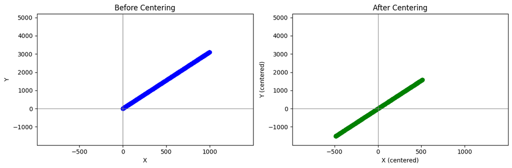

```python
padding = 500

def visualizeCentering(x, y, xCentered, yCentered):
    xRaw = [row[0] for row in x]
    xCent = [row[0] for row in xCentered]

    allX = xRaw + xCent
    allY = y + yCentered
    xMin, xMax = min(allX) - padding, max(allX) + padding
    yMin, yMax = min(allY) - padding, max(allY) + padding

    fig, axs = plt.subplots(1, 2, figsize=(12, 4))

    axs[0].scatter(xRaw, y, color='blue')
    axs[0].set_title("Before Centering")
    axs[0].set_xlabel("X")
    axs[0].set_ylabel("Y")
    axs[0].axhline(0, color='gray', linewidth=0.8)
    axs[0].axvline(0, color='gray', linewidth=0.8)
    axs[0].set_xlim(xMin, xMax)
    axs[0].set_ylim(yMin, yMax)

    axs[1].scatter(xCent, yCentered, color='green')
    axs[1].set_title("After Centering")
    axs[1].set_xlabel("X (centered)")
    axs[1].set_ylabel("Y (centered)")
    axs[1].axhline(0, color='gray', linewidth=0.8)
    axs[1].axvline(0, color='gray', linewidth=0.8)
    axs[1].set_xlim(xMin, xMax)
    axs[1].set_ylim(yMin, yMax)

    plt.tight_layout()
    plt.show()

folderName = "Linearna funkcija"
# folderName = "Polinomska funkcija"

filePath = os.path.join("TestniPodatki", folderName, "Podatki.txt")
x, y = loadData(filePath)

if x.shape[1] == 1 and folderName == "Polinomska funkcija":
    degree = 4
    x = addPolynomialFeatures(x, degree)
else:
    degree = 1

xList = x
yList = y

xMeans = meanColumn(xList)
yMean = sum(yList) / len(yList)

xCentered = centerMatrix(xList, xMeans)
yCentered = centerVector(yList, yMean)
if "Linearna funkcija" in filePath or "Polinomska funkcija" in filePath:
    visualizeCentering(xList, yList, xCentered, yCentered)
```

## Run all test cases

This runs regressionall datasets.

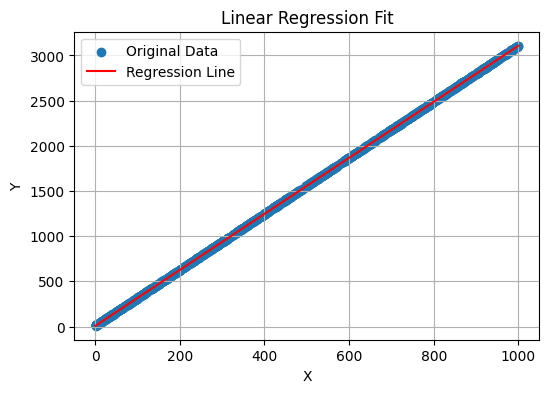

```
Linearna funkcija:
Coefficients:
b0 = 7.2
b1 = 3.1

=======================================
```

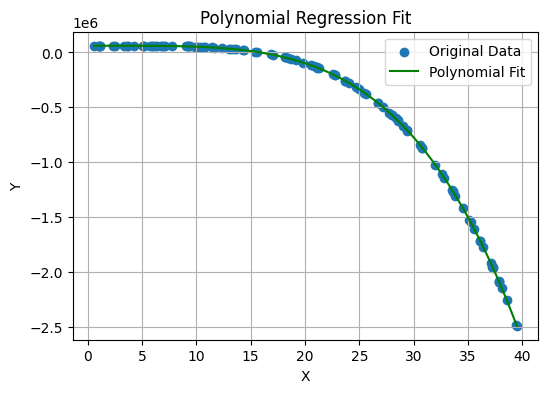

```
Polinomska funkcija:
Coefficients:
b0 = 61005.0
b1 = 5.6
b2 = -0.0
b3 = 2.1
b4 = -1.1

=======================================

Multivariable regression model:
y = 1.04 + 0.1*x1 + 11.1*x2 + 5.2*x3 + 4.4*x4

Multilinearna funkcija:
Coefficients:
b0 = 1.0
b1 = 0.1
b2 = 11.1
b3 = 5.2
b4 = 4.4

=======================================
```

```python
runRegressionFromFolder("Linearna funkcija")
runRegressionFromFolder("Polinomska funkcija")
runRegressionFromFolder("Multilinearna funkcija")
```